# R Notebook

# Libraries

```r
library(randomForest)
```

#Data

```r
aggregate_dataset <- read_csv("data/shs_aggregate_responses.csv") %>% clean_names()
```

## Notes about the dataset

- There are some NAs in the data, namely in the following rows
  - Satisfaction with nearest greenspace (9988 missing)
  - Economic status (1 missing)
  - Highest education level (10920 missing)
  - Nearest green space use (16766 missing)
  - Volunteering last twelve months (6778)

Can we meaningfully impute these?

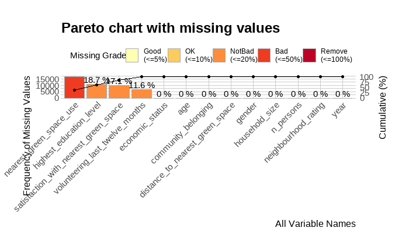

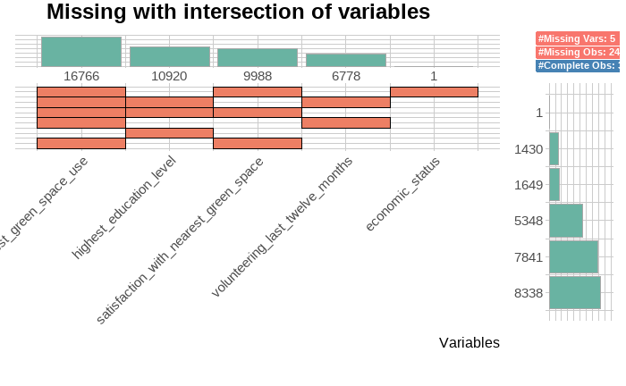

Community belonging - Don’t know - 576 Neighbourhood rating - No opinion - 190 Satisfaction with nearest greenspace - No opinion - 3418 Nearest green space use - Don’t know - 83 Distance to nearest green space - Don’t know - 386

To Impute or not Impute: That’s the Question - Lodder, 2013 “If more than 25% of the data is missing and researchers apply modern treatments to impute the missing data, then they should always compare the results of their subsequent analyses with the results they would have obtained if they had used complete case analysis.” (Lodder, 2013)

So we can try using the MissRanger package to compute missing categorical variables using the random forest method (https://yuzar-blog.netlify.app/posts/2021-03-04-how-to-impute-missing-values-in-r/#multivariate-imputation-of-categorical-variables)

We can then compare the results to the complete case analysis (only complete observations are included - meaning all NAs are dropped)

## Test/train split

```r
n_data <- nrow(aggregate_dataset)
test_index <- sample(1:n_data, size = n_data*0.2)
agg_dataset_test <- slice(aggregate_dataset, test_index)
agg_dataset_train <- slice(aggregate_dataset, -test_index)
```

### Imputation for train dataset

```r
train_dataset_imputed <- missRanger(
  agg_dataset_train,
  formula = . ~ .,
  num.trees = 100,
  verbose = 2,
  seed = 111,
  returnOOB = TRUE

)
```

```
Missing value imputation by random forests

  Variables to impute:      satisfaction_with_nearest_green_space, economic_status, highest_education_level, nearest_green_space_use, volunteering_last_twelve_months
  Variables used to impute: year, community_belonging, neighbourhood_rating, distance_to_nearest_green_space, satisfaction_with_nearest_green_space, age, gender, economic_status, household_size, highest_education_level, nearest_green_space_use, volunteering_last_twelve_months, n_persons
    ecnmc_  vln___  st____  hghs__  nrs___
iter 1: 0.4501  0.2932  0.5767  0.6392  0.7079
iter 2: 0.0011  0.0000  0.0012  0.0022  0.0031
iter 3: 0.0011  0.0000  0.0011  0.0015  0.0053
```

### Imputation for test dataset

```r
test_dataset_imputed <- missRanger(
  agg_dataset_test,
  formula = . ~ .,
  num.trees = 100,
  verbose = 2,
  seed = 111,
  returnOOB = TRUE
)
```

```
Missing value imputation by random forests

  Variables to impute:      satisfaction_with_nearest_green_space, highest_education_level, nearest_green_space_use, volunteering_last_twelve_months
  Variables used to impute: year, community_belonging, neighbourhood_rating, distance_to_nearest_green_space, satisfaction_with_nearest_green_space, age, gender, economic_status, household_size, highest_education_level, nearest_green_space_use, volunteering_last_twelve_months, n_persons
    vln___  st____  hghs__  nrs___
iter 1: 0.3062  0.5951  0.6650  0.7152
iter 2: 0.0000  0.0029  0.0040  0.0108
iter 3: 0.0000  0.0048  0.0046  0.0103
```

# Community belonging

```r
train_comm_belonging <- train_dataset_imputed %>%
  #take out don't know b/c we want to predict strong/weak belonging
  filter(community_belonging != "Don't know") %>%
   #create binary version of community belonging
  mutate(community_belonging_binary = if_else(community_belonging %in% c(
    "Very strongly", "Fairly strongly"), "Strong", "Not strong"), .after =
      community_belonging) %>%
  #factor all the categorical variables
  mutate(neighbourhood_rating = factor(neighbourhood_rating, levels =
                                         c("Very good",
                                           "Fairly good",
                                           "Fairly poor",
                                           "Very poor",
                                           "No opinion")),
         distance_to_nearest_green_space = factor(distance_to_nearest_green_space,
                                                  levels = c(
                                                    "A 5 minute walk or less",
                                                    "Within a 6-10 minute walk",
                                                    "Within an 11-20 minute walk",
                                                    "Within a 21-30 minute walk",
                                                    "More than a 30 minute walk away",
                                                    "Don't know"
                                                  )),
         satisfaction_with_nearest_green_space = factor(
           satisfaction_with_nearest_green_space,
           levels = c("Very satisfied",
                      "Fairly satisfied",
                      "Neither satisfied nor dissatisfied",
                      "Fairly dissatisfied",
                      "Very dissatisfied",
                      "No opinion"
                      )),
         age = factor(age, levels = c(
           "16 - 34 Years",
           "35 - 64 Years",
           "65 + Years"
         )),
         gender = as.factor(gender),
         economic_status = as.factor(economic_status),
         highest_education_level = factor(highest_education_level, levels =
                                            c(
                                              "Standard grade or equiv (SVQ level 1 or 2).",
                                              "Higher, A level or equivalent (SVQ Level 3)",
                                              "HNC/HND or equivalent (SVQ Level 4)",
                                              "Degree, Professional qualification (Above SVQ Level 4)",
                                              "Other qualification"
                                            )),
         nearest_green_space_use = as.factor(nearest_green_space_use),
         volunteering_last_twelve_months = as.factor(volunteering_last_twelve_months),
         community_belonging_binary = as.factor(community_belonging_binary)
         ) %>%
  #take out original community belonging and the n_persons column (the number of people with the same observed characteristics isn't useful to the model)
  select(-c(community_belonging, n_persons))
```

```r
community_rf_classifier <- ranger(community_belonging_binary ~ .,
                                  data = train_comm_belonging,
                                  importance = "impurity",
                                  num.trees = 500)
```

```r
community_rf_classifier
```

```
Ranger result

Call:
 ranger(community_belonging_binary ~ ., data = train_comm_belonging,      importance = "impurity", num.trees = 500)

Type:                             Classification
Number of trees:                  500
Sample size:                      46364
Number of independent variables:  11
Mtry:                             3
Target node size:                 1
Variable importance mode:         impurity
Splitrule:                        gini
OOB prediction error:             22.25 %
```

```r
importance(community_rf_classifier)
```

```
                                 year                  neighbourhood_rating       distance_to_nearest_green_space satisfaction_with_nearest_green_space
                            1391.8404                             1891.3951                              870.5665                              838.6626
                                  age                                gender                       economic_status                        household_size
                             390.1987                              409.2960                              757.2584                              890.3340
              highest_education_level               nearest_green_space_use       volunteering_last_twelve_months
                             881.8984                             1161.3930                              235.2001
```

```r
community_rf_classifier$confusion.matrix
```

```
            predicted
true         Not strong Strong
  Not strong       2602   8709
  Strong           1606  33447
```

```r
#testing to see whether a different value for mtry will be better than the default
oob_values <- vector(length = 10)
for(i in 1:10) {
  temp.model <- ranger(community_belonging_binary ~ .,
                       data = train_comm_belonging,
                       importance = "impurity",
                       num.trees = 500,
                       mtry = i)
  oob_values[i] <- temp.model$prediction.error
}
oob_values
```

```
 [1] 0.2429687 0.2196747 0.2236002 0.2331335 0.2434648 0.2514235 0.2556078 0.2576352 0.2604176 0.2611725
```

```r
community_rf_classifier <- ranger(community_belonging_binary ~ .,
                                  data = train_comm_belonging,
                                  importance = "permutation",
                                  num.trees = 50,
                                  mtry = 2)
```

```r
importance(community_rf_classifier)
```

```
                                 year                  neighbourhood_rating       distance_to_nearest_green_space satisfaction_with_nearest_green_space
                          0.002058263                           0.039416165                           0.002483461                           0.004405748
                                  age                                gender                       economic_status                        household_size
                          0.013134302                           0.001103914                           0.007916491                           0.004549042
              highest_education_level               nearest_green_space_use       volunteering_last_twelve_months
                          0.005746116                           0.004237777                           0.001646529
```

```r
head(importance_pvalues(community_rf_classifier, formula = community_belonging_binary ~ .,
                        data = train_comm_belonging, method = "altmann"))
```

```
                                       importance     pvalue
year                                  0.002058263 0.28712871
neighbourhood_rating                  0.039416165 0.00990099
distance_to_nearest_green_space       0.002483461 0.26732673
satisfaction_with_nearest_green_space 0.004405748 0.08910891
age                                   0.013134302 0.00990099
gender                                0.001103914 0.36633663
```

# Neighbourhood rating

## Prepare training dataset

```r
train_neighbourhood_rating <- train_dataset_imputed %>%
  #take out don't know b/c we want to predict good/poor ratings
  filter(neighbourhood_rating != "No opinion") %>%
   #create binary version of neighbourhood rating
  mutate(neighbourhood_rating_binary = if_else(neighbourhood_rating %in% c(
    "Very good", "Fairly good"), "Good", "Poor"), .after =
      neighbourhood_rating) %>%
  #factor all the categorical variables
  mutate(community_belonging = factor(community_belonging, levels =
                                         c("Very strongly",
                                           "Fairly strongly",
                                           "Not very strongly",
                                           "Not at all strongly",
                                           "Don't know")),
         distance_to_nearest_green_space = factor(distance_to_nearest_green_space,
                                                  levels = c(
                                                    "A 5 minute walk or less",
                                                    "Within a 6-10 minute walk",
                                                    "Within an 11-20 minute walk",
                                                    "Within a 21-30 minute walk",
                                                    "More than a 30 minute walk away",
                                                    "Don't know"
                                                  )),
         satisfaction_with_nearest_green_space = factor(
           satisfaction_with_nearest_green_space,
           levels = c("Very satisfied",
                      "Fairly satisfied",
                      "Neither satisfied nor dissatisfied",
                      "Fairly dissatisfied",
                      "Very dissatisfied",
                      "No opinion"
                      )),
         age = factor(age, levels = c(
           "16 - 34 Years",
           "35 - 64 Years",
           "65 + Years"
         )),
         gender = as.factor(gender),
         economic_status = as.factor(economic_status),
         highest_education_level = factor(highest_education_level, levels =
                                            c(
                                              "Standard grade or equiv (SVQ level 1 or 2).",
                                              "Higher, A level or equivalent (SVQ Level 3)",
                                              "HNC/HND or equivalent (SVQ Level 4)",
                                              "Degree, Professional qualification (Above SVQ Level 4)",
                                              "Other qualification"
                                            )),
         nearest_green_space_use = as.factor(nearest_green_space_use),
         volunteering_last_twelve_months = as.factor(volunteering_last_twelve_months),
         neighbourhood_rating_binary = as.factor(neighbourhood_rating_binary)
         ) %>%
  #take out original neighbourhood rating and the n_persons column (the number of people with the same observed characteristics isn't useful to the model)
  select(-c(neighbourhood_rating, n_persons))
```

## Random forest model

```r
#testing to see whether a different value for mtry will be better than the default
oob_values <- vector(length = 7)
for(i in 1:7) {
  temp.model <- ranger(neighbourhood_rating_binary ~ .,
                       data = train_neighbourhood_rating,
                       importance = "impurity",
                       num.trees = 500,
                       mtry = i)
  oob_values[i] <- temp.model$prediction.error
}
oob_values
```

```
[1] 0.06483823 0.06355260 0.06380973 0.06599529 0.06841654 0.07055925 0.07233769
```

Based on this output, a value of mtry = 2 is the best for this data.

```r
neighbourhood_rf_classifier
```

```
Ranger result

Call:
 ranger(neighbourhood_rating_binary ~ ., data = train_neighbourhood_rating,      importance = "impurity", num.trees = 1000, mtry = 2)

Type:                             Classification
Number of trees:                  1000
Sample size:                      46673
Number of independent variables:  11
Mtry:                             2
Target node size:                 1
Variable importance mode:         impurity
Splitrule:                        gini
OOB prediction error:             6.25 %
```

```r
importance(neighbourhood_rf_classifier)
```

```
                                 year                   community_belonging       distance_to_nearest_green_space
                            320.39722                             641.13830                             208.75051
satisfaction_with_nearest_green_space                                   age                                gender
                            288.20002                             112.91049                              96.19526
                      economic_status                        household_size               highest_education_level
                            209.60829                             217.72272                             206.99817
              nearest_green_space_use       volunteering_last_twelve_months
                            242.84857                              62.88201
```

```r
neighbourhood_rf_100 <- ranger(neighbourhood_rating_binary ~ .,
                                  data = train_neighbourhood_rating,
                                  importance = "permutation",
                                  num.trees = 100,
                                  mtry = 2)

importance_pvalues(neighbourhood_rf_100,
                   formula = neighbourhood_rating_binary ~ .,
                   method = "altmann",
                   data = train_neighbourhood_rating,
                   num.permutations = 50)
```

```
                                        importance     pvalue
year                                  0.0034716964 0.01960784
community_belonging                   0.0097909489 0.01960784
distance_to_nearest_green_space       0.0013092735 0.64705882
satisfaction_with_nearest_green_space 0.0064289795 0.01960784
age                                   0.0028224710 1.00000000
gender                                0.0004623142 0.70588235
economic_status                       0.0038460851 0.98039216
household_size                        0.0013444982 0.82352941
highest_education_level               0.0011476639 1.00000000
nearest_green_space_use               0.0031533502 0.41176471
volunteering_last_twelve_months       0.0005785310 0.86274510
```

It looks like the most important variables were year, community belonging, and satisfaction with nearest greenspace - all the rest were nonsignificant

```r
neighbourhood_rf_classifier$confusion.matrix
```

```
      predicted
true    Good  Poor
  Good 43588    73
  Poor  2845   167
```

```r
#true positive rate
43588/(43588 + 73)
```

```
[1] 0.998328
```

```r
#true negative rate
167/(167 + 2845)
```

```
[1] 0.05544489
```

```r
#false positive rate
2845/(167 + 2845)
```

```
[1] 0.9445551
```

```r
#false negative rate
73/(73 + 43588)
```

```
[1] 0.001671973
```

```r
rf_nrating_classifier <- randomForest(formula = neighbourhood_rating_binary ~ .,
                                      data = train_neighbourhood_rating,
                                      ntree = 1000,
                                      norm.votes = FALSE)
```

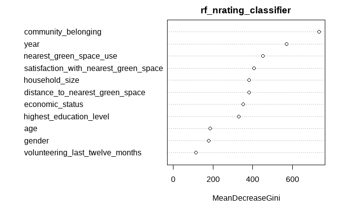

We’re getting slightly different variables that are most important in the model generated with random forest package

### Test on the test dataset

```r
#Impute the test dataset using the same imputation method as before
test_neighbourhood_rating <- test_dataset_imputed %>%
  #take out don't know b/c we want to predict good/poor ratings
  filter(neighbourhood_rating != "No opinion") %>%
   #create binary version of neighbourhood rating
  mutate(neighbourhood_rating_binary = if_else(neighbourhood_rating %in% c(
    "Very good", "Fairly good"), "Good", "Poor"), .after =
      neighbourhood_rating) %>%
  #factor all the categorical variables
  mutate(community_belonging = factor(community_belonging, levels =
                                         c("Very strongly",
                                           "Fairly strongly",
                                           "Not very strongly",
                                           "Not at all strongly",
                                           "Don't know")),
         distance_to_nearest_green_space = factor(distance_to_nearest_green_space,
                                                  levels = c(
                                                    "A 5 minute walk or less",
                                                    "Within a 6-10 minute walk",
                                                    "Within an 11-20 minute walk",
                                                    "Within a 21-30 minute walk",
                                                    "More than a 30 minute walk away",
                                                    "Don't know"
                                                  )),
         satisfaction_with_nearest_green_space = factor(
           satisfaction_with_nearest_green_space,
           levels = c("Very satisfied",
                      "Fairly satisfied",
                      "Neither satisfied nor dissatisfied",
                      "Fairly dissatisfied",
                      "Very dissatisfied",
                      "No opinion"
                      )),
         age = factor(age, levels = c(
           "16 - 34 Years",
           "35 - 64 Years",
           "65 + Years"
         )),
         gender = as.factor(gender),
         economic_status = as.factor(economic_status),
         highest_education_level = factor(highest_education_level, levels =
                                            c(
                                              "Standard grade or equiv (SVQ level 1 or 2).",
                                              "Higher, A level or equivalent (SVQ Level 3)",
                                              "HNC/HND or equivalent (SVQ Level 4)",
                                              "Degree, Professional qualification (Above SVQ Level 4)",
                                              "Other qualification"
                                            )),
         nearest_green_space_use = as.factor(nearest_green_space_use),
         volunteering_last_twelve_months = as.factor(volunteering_last_twelve_months),
         neighbourhood_rating_binary = as.factor(neighbourhood_rating_binary)
         ) %>%
  #take out original neighbourhood rating and the n_persons column (the number of people with the same observed characteristics isn't useful to the model)
  select(-c(neighbourhood_rating, n_persons))
```

After trying to get the predictions to work on the model generated using the ranger package, I eventually had to use the random forests package in order to get probabilities as I couldn’t figure out how to get them to work with the ranger model.

```r
auc(roc_obj_nrating_tree)
```

```
Area under the curve: 0.7744
```

```r
#check the confusion table
test_nrating_pred %>%
  tabyl(neighbourhood_rating_binary, pred) %>%
  adorn_title()
```

```
                             pred
 neighbourhood_rating_binary Poor  Good
                        Good   23 10846
                        Poor   37   761
```

```r
#true positive rate
10846/(10846 + 23)
```

```
[1] 0.9978839
```

```r
#true negative rate
37/(37 + 761)
```

```
[1] 0.04636591
```

```r
#false positive rate
761/(37 + 761)
```

```
[1] 0.9536341
```

```r
#false negative rate
23/(23 + 10846)
```

```
[1] 0.00211611
```

## Logistic regression

| year | community_belonging | distance_to_nearest_green_space | satisfaction_with_nearest_green_space | age | gender | economic_status | household_size | highest_education_level | nearest_green_space_use | volunteering_last_twelve_months | neighbourhood_rating_good |
| --- | --- | --- | --- | --- | --- | --- | --- | --- | --- | --- | --- |
| 2012 | Don't know | Within 10 minutes | Fairly satisfied | 16 - 34 Years | Female | Full Time Employment | 1 | Degree, Professional qualification (Above SVQ Level 4) | Once a week | No | TRUE |
| 2012 | Don't know | Within 10 minutes | Fairly satisfied | 16 - 34 Years | Female | Full Time Employment | 2 | HNC/HND or equivalent (SVQ Level 4) | Several times a week | No | TRUE |
| 2012 | Don't know | Within 10 minutes | Fairly satisfied | 16 - 34 Years | Female | Part Time Employment | 2 | Degree, Professional qualification (Above SVQ Level 4) | Once a week | No | TRUE |
| 2012 | Don't know | Within 10 minutes | Fairly satisfied | 16 - 34 Years | Male | Part Time Employment | 2 | Degree, Professional qualification (Above SVQ Level 4) | Once a week | No | TRUE |
| 2012 | Don't know | Within 10 minutes | Fairly satisfied | 16 - 34 Years | Male | Training | 1 | Degree, Professional qualification (Above SVQ Level 4) | Several times a week | No | TRUE |
| 2012 | Don't know | Within 10 minutes | Fairly satisfied | 16 - 34 Years | Male | Training | 2 | HNC/HND or equivalent (SVQ Level 4) | Once a month | No | TRUE |
| 2012 | Don't know | Within 10 minutes | Fairly satisfied | 35 - 64 Years | Female | Other | 1 | Standard grade or equiv (SVQ level 1 or 2). | Several times a month | No | TRUE |
| 2012 | Don't know | Within 10 minutes | Fairly satisfied | 35 - 64 Years | Male | Full Time Employment | 1 | Degree, Professional qualification (Above SVQ Level 4) | Once a week | No | TRUE |
| 2012 | Don't know | Within 10 minutes | Fairly satisfied | 35 - 64 Years | Male | Other | 1 | Standard grade or equiv (SVQ level 1 or 2). | Not at all | No | TRUE |
| 2012 | Don't know | Within 10 minutes | Fairly satisfied | 65 + Years | Female | Retired | 1 | Degree, Professional qualification (Above SVQ Level 4) | Several times a week | Yes | TRUE |

[output cut: 990 more lines]

```r
alias(neighbourhood_rating_good ~ ., data = train_nrating_regression)
```

```
Model :
neighbourhood_rating_good ~ year + community_belonging + distance_to_nearest_green_space +
    satisfaction_with_nearest_green_space + age + gender + economic_status +
    household_size + highest_education_level + nearest_green_space_use +
    volunteering_last_twelve_months
```

```r
glmulti_search_all_mains <- glmulti(
  neighbourhood_rating_good ~ .,
  data = train_nrating_regression,
  level = 1,
  method = "h",
  crit = "bic",
  confsetsize = 10,
  plotty = F,
  report = T,
  fitfunction = "glm",
  family = binomial(link = "logit")
)
```

```
Initialization...
TASK: Exhaustive screening of candidate set.
Fitting...

After 50 models:
Best model: neighbourhood_rating_good~1+community_belonging+satisfaction_with_nearest_green_space+household_size
Crit= 18235.3885909149
Mean crit= 18381.9747507252

After 100 models:
Best model: neighbourhood_rating_good~1+community_belonging+satisfaction_with_nearest_green_space+age+year+household_size
Crit= 18222.9521187706
Mean crit= 18230.512259862

After 150 models:
Best model: neighbourhood_rating_good~1+community_belonging+satisfaction_with_nearest_green_space+age+gender+year+household_size
Crit= 18218.3869197946
Mean crit= 18223.8059937963

After 200 models:
Best model: neighbourhood_rating_good~1+community_belonging+satisfaction_with_nearest_green_space+economic_status+year+household_size
Crit= 17969.3866817588
Mean crit= 17977.673526877

After 250 models:
Best model: neighbourhood_rating_good~1+community_belonging+satisfaction_with_nearest_green_space+economic_status+year+household_size
Crit= 17969.3866817588
Mean crit= 17975.5936138886

After 300 models:
Best model: neighbourhood_rating_good~1+community_belonging+satisfaction_with_nearest_green_space+economic_status+year+household_size
Crit= 17969.3866817588
Mean crit= 17974.7578809379

After 350 models:
Best model: neighbourhood_rating_good~1+community_belonging+satisfaction_with_nearest_green_space+age+highest_education_level+year+household_size
Crit= 17965.0759568696
Mean crit= 17970.5935849715

After 400 models:
```

[output cut: 159 more lines]

```
After 2000 models:
Best model: neighbourhood_rating_good~1+community_belonging+satisfaction_with_nearest_green_space+economic_status+highest_education_level+year+household_size
Crit= 17851.0411437102
Mean crit= 17856.3102126802

After 2050 models:
Best model: neighbourhood_rating_good~1+community_belonging+satisfaction_with_nearest_green_space+economic_status+highest_education_level+year+household_size
Crit= 17851.0411437102
Mean crit= 17856.3102126802

After 2100 models:
Best model: neighbourhood_rating_good~1+community_belonging+satisfaction_with_nearest_green_space+economic_status+highest_education_level+year+household_size
Crit= 17851.0411437102
Mean crit= 17856.3102126802
Completed.
```

```r
summary(glmulti_search_all_mains)
```

```
$name
[1] "glmulti.analysis"

$method
[1] "h"

$fitting
[1] "glm"

$crit
[1] "bic"

$level
[1] 1

$marginality
[1] FALSE

$confsetsize
[1] 10

$bestic
[1] 17851.04

$icvalues
 [1] 17851.04 17852.43 17853.75 17855.21 17855.86 17857.65 17858.57 17859.12 17859.53 17859.92

$bestmodel
[1] "neighbourhood_rating_good ~ 1 + community_belonging + satisfaction_with_nearest_green_space + "
[2] "    economic_status + highest_education_level + year + household_size"

$modelweights
 [1] 0.482149712 0.240451285 0.124393512 0.059845672 0.043236347 0.017669006 0.011180034 0.008478429 0.006907257 0.005688745

$includeobjects
[1] TRUE
```

| model | bic | weights |
| --- | --- | --- |
| neighbourhood_rating_good ~ 1 + community_belonging + satisfaction_with_nearest_green_space + economic_status + highest_education_level + year + household_size | 17851.04 | 0.482149712 |
| neighbourhood_rating_good ~ 1 + community_belonging + satisfaction_with_nearest_green_space + economic_status + highest_education_level + household_size | 17852.43 | 0.240451285 |
| neighbourhood_rating_good ~ 1 + community_belonging + satisfaction_with_nearest_green_space + gender + economic_status + highest_education_level + year + household_size | 17853.75 | 0.124393512 |
| neighbourhood_rating_good ~ 1 + community_belonging + satisfaction_with_nearest_green_space + gender + economic_status + highest_education_level + household_size | 17855.21 | 0.059845672 |
| neighbourhood_rating_good ~ 1 + community_belonging + distance_to_nearest_green_space + satisfaction_with_nearest_green_space + economic_status + highest_education_level + year + household_size | 17855.86 | 0.043236347 |
| neighbourhood_rating_good ~ 1 + community_belonging + satisfaction_with_nearest_green_space + economic_status + highest_education_level + volunteering_last_twelve_months + year + household_size | 17857.65 | 0.017669006 |
| neighbourhood_rating_good ~ 1 + community_belonging + distance_to_nearest_green_space + satisfaction_with_nearest_green_space + economic_status + highest_education_level + household_size | 17858.57 | 0.011180034 |
| neighbourhood_rating_good ~ 1 + community_belonging + distance_to_nearest_green_space + satisfaction_with_nearest_green_space + gender + economic_status + highest_education_level + year + household_si… | 17859.12 | 0.008478429 |
| neighbourhood_rating_good ~ 1 + community_belonging + satisfaction_with_nearest_green_space + economic_status + highest_education_level + year | 17859.53 | 0.006907257 |
| neighbourhood_rating_good ~ 1 + community_belonging + satisfaction_with_nearest_green_space + gender + economic_status + highest_education_level + volunteering_last_twelve_months + year + household_si… | 17859.92 | 0.005688745 |

```r
summary(mod_nrating_no_econ)
```

```
Call:
glm(formula = neighbourhood_rating_good ~ community_belonging +
    satisfaction_with_nearest_green_space + highest_education_level +
    year + household_size, family = binomial(link = "logit"),
    data = train_nrating_regression)

Deviance Residuals:
    Min       1Q   Median       3Q      Max
-3.2366   0.1584   0.2294   0.3289   1.6897

Coefficients:
                                                                               Estimate Std. Error z value Pr(>|z|)
(Intercept)                                                                   64.372682  18.074911   3.561 0.000369 ***
community_belongingFairly strongly                                            -0.528271   0.070135  -7.532 4.99e-14 ***
community_belongingNot very strongly                                          -1.885235   0.067469 -27.942  < 2e-16 ***
community_belongingNot at all strongly                                        -3.161209   0.070689 -44.720  < 2e-16 ***
community_belongingDon't know                                                 -1.052275   0.233951  -4.498 6.86e-06 ***
satisfaction_with_nearest_green_spaceFairly satisfied                         -0.819509   0.060606 -13.522  < 2e-16 ***
satisfaction_with_nearest_green_spaceNeither satisfied nor dissatisfied       -1.311837   0.076153 -17.226  < 2e-16 ***
satisfaction_with_nearest_green_spaceFairly dissatisfied                      -1.556428   0.086034 -18.091  < 2e-16 ***
satisfaction_with_nearest_green_spaceVery dissatisfied                        -2.042509   0.094194 -21.684  < 2e-16 ***
satisfaction_with_nearest_green_spaceNo opinion                               -0.932769   0.087750 -10.630  < 2e-16 ***
highest_education_levelHigher, A level or equivalent (SVQ Level 3)             0.530313   0.059640   8.892  < 2e-16 ***
highest_education_levelHNC/HND or equivalent (SVQ Level 4)                     0.564278   0.069197   8.155 3.50e-16 ***
highest_education_levelDegree, Professional qualification (Above SVQ Level 4)  0.880075   0.052657  16.713  < 2e-16 ***
highest_education_levelOther qualification                                     0.266576   0.081203   3.283 0.001028 **
year                                                                          -0.029912   0.008968  -3.335 0.000852 ***
household_size                                                                 0.070755   0.017914   3.950 7.82e-05 ***
---
Signif. codes:  0 ‘***’ 0.001 ‘**’ 0.01 ‘*’ 0.05 ‘.’ 0.1 ‘ ’ 1

(Dispersion parameter for binomial family taken to be 1)

    Null deviance: 22334  on 46672  degrees of freedom
Residual deviance: 17804  on 46657  degrees of freedom
AIC: 17836

Number of Fisher Scoring iterations: 6
```

```r
#Take this result and get a percentage
1-0.04242574
```

```
[1] 0.9575743
```

```r
stats::confint(mod_nrating_no_econ, 'household_size', level = 0.95)
```

```
    2.5 %    97.5 %
0.0358125 0.1060422
```

### Get odds ratio for model coefficients

```r
odds.ratio(mod_nrating_no_econ, level = 0.95)
```

```
                                                                                                               OR
(Intercept)                                                                   9051085596399754459028688866.000000
community_belongingFairly strongly                                                                       0.589624
community_belongingNot very strongly                                                                     0.151793
community_belongingNot at all strongly                                                                   0.042374
community_belongingDon't know                                                                            0.349143
satisfaction_with_nearest_green_spaceFairly satisfied                                                    0.440648
satisfaction_with_nearest_green_spaceNeither satisfied nor dissatisfied                                  0.269325
satisfaction_with_nearest_green_spaceFairly dissatisfied                                                 0.210888
satisfaction_with_nearest_green_spaceVery dissatisfied                                                   0.129703
satisfaction_with_nearest_green_spaceNo opinion                                                          0.393463
highest_education_levelHigher, A level or equivalent (SVQ Level 3)                                       1.699464
highest_education_levelHNC/HND or equivalent (SVQ Level 4)                                               1.758178
highest_education_levelDegree, Professional qualification (Above SVQ Level 4)                            2.411081
highest_education_levelOther qualification                                                               1.305486
year                                                                                                     0.970531
household_size                                                                                           1.073318
                                                                                                            2.5 %
(Intercept)                                                                                  3659941133625.334473
community_belongingFairly strongly                                                                       0.513352
community_belongingNot very strongly                                                                     0.132814
community_belongingNot at all strongly                                                                   0.036845
community_belongingDon't know                                                                            0.226137
satisfaction_with_nearest_green_spaceFairly satisfied                                                    0.390894
satisfaction_with_nearest_green_spaceNeither satisfied nor dissatisfied                                  0.231947
satisfaction_with_nearest_green_spaceFairly dissatisfied                                                 0.178237
satisfaction_with_nearest_green_spaceVery dissatisfied                                                   0.107898
satisfaction_with_nearest_green_spaceNo opinion                                                          0.331502
highest_education_levelHigher, A level or equivalent (SVQ Level 3)                                       1.512912
highest_education_levelHNC/HND or equivalent (SVQ Level 4)                                               1.536959
highest_education_levelDegree, Professional qualification (Above SVQ Level 4)                            2.175348
highest_education_levelOther qualification                                                               1.115405
year                                                                                                     0.953626
household_size                                                                                           1.036461
                                                                                                                         97.5 %
(Intercept)                                                                   21748033032343362888480068686048006428004268.0000
community_belongingFairly strongly                                                                                       0.6759
community_belongingNot very strongly                                                                                     0.1730
community_belongingNot at all strongly                                                                                   0.0486
community_belongingDon't know                                                                                            0.5684
```

[output cut: 15 more lines]

```
community_belongingNot at all strongly                                        < 0.00000000000000022 ***
community_belongingDon't know                                                 0.0000068645463395125 ***
satisfaction_with_nearest_green_spaceFairly satisfied                         < 0.00000000000000022 ***
satisfaction_with_nearest_green_spaceNeither satisfied nor dissatisfied       < 0.00000000000000022 ***
satisfaction_with_nearest_green_spaceFairly dissatisfied                      < 0.00000000000000022 ***
satisfaction_with_nearest_green_spaceVery dissatisfied                        < 0.00000000000000022 ***
satisfaction_with_nearest_green_spaceNo opinion                               < 0.00000000000000022 ***
highest_education_levelHigher, A level or equivalent (SVQ Level 3)            < 0.00000000000000022 ***
highest_education_levelHNC/HND or equivalent (SVQ Level 4)                    0.0000000000000003502 ***
highest_education_levelDegree, Professional qualification (Above SVQ Level 4) < 0.00000000000000022 ***
highest_education_levelOther qualification                                                0.0010278 **
year                                                                                      0.0008519 ***
household_size                                                                0.0000782406023842452 ***
---
Signif. codes:  0 ‘***’ 0.001 ‘**’ 0.01 ‘*’ 0.05 ‘.’ 0.1 ‘ ’ 1
```

```r
ll.null <- mod_nrating_no_econ$null.deviance/-2
ll.proposed <- mod_nrating_no_econ$deviance/-2

(ll.null - ll.proposed)/ll.null
```

```
[1] 0.2028595
```

```r
#get p value for R^2
1 - pchisq(2*(ll.proposed - ll.null), df=(length(mod_nrating_no_econ$coefficients)-1))
```

```
[1] 0
```

```r
exp(.344)
```

```
[1] 1.410579
```

| highest_education_level |
| --- |
| Degree, Professional qualification (Above SVQ Level 4) |
| HNC/HND or equivalent (SVQ Level 4) |
| Standard grade or equiv (SVQ level 1 or 2). |
| Higher, A level or equivalent (SVQ Level 3) |
| Other qualification |

```r
exp(2.006943)
```

```
[1] 7.440537
```

```r
exp(0.662114)
```

```
[1] 1.938887
```

```r
exp(0.064584)
```

```
[1] 1.066715
```

### Confusion matrix

```r
nrating_regression_preds <- train_nrating_regression %>%
  # add our predicted probabilities from the log model
  add_predictions(mod_nrating_no_econ, type = "response") %>%
    mutate(predicted_good = pred >= 0.6)

conf_mat <- nrating_regression_preds %>%
  tabyl(neighbourhood_rating_good, predicted_good) %>%
  adorn_title()
```

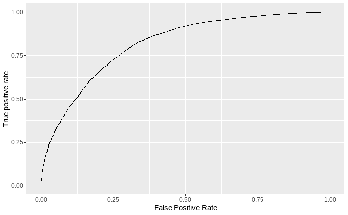

```r
roc_obj_nrating <- nrating_regression_preds %>%
  roc(response = neighbourhood_rating_good, predictor = pred)#predictor is the probability column
ggroc(data = roc_obj_nrating, legacy.axes = TRUE)+
  labs(x = "False Positive Rate", y = "True positive rate")
```

```r
#get auc for training model
auc(roc_obj_nrating)
```

```
Area under the curve: 0.8179
```

### Test on the test dataset

```r
#format the test dataset using the same method as the train dataset

test_nrating_regression <- test_dataset_imputed %>%
  #take out don't know b/c we want to predict good/poor ratings
  filter(neighbourhood_rating != "No opinion") %>%
   #create binary version of neighbourhood rating
  mutate(neighbourhood_rating_binary = if_else(neighbourhood_rating %in% c(
    "Very good", "Fairly good"), "Good", "Poor"), .after =
      neighbourhood_rating) %>%
  #factor all the categorical variables
  mutate(community_belonging = factor(community_belonging, levels =
                                         c("Very strongly",
                                           "Fairly strongly",
                                           "Not very strongly",
                                           "Not at all strongly",
                                           "Don't know")),
         satisfaction_with_nearest_green_space = factor(
           satisfaction_with_nearest_green_space,
           levels = c("Very satisfied",
                      "Fairly satisfied",
                      "Neither satisfied nor dissatisfied",
                      "Fairly dissatisfied",
                      "Very dissatisfied",
                      "No opinion"
                      )),
         age = factor(age, levels = c(
           "16 - 34 Years",
           "35 - 64 Years",
           "65 + Years"
         )),
         gender = as.factor(gender),
         economic_status = as.factor(economic_status),
         highest_education_level = factor(highest_education_level, levels =
                                            c(
                                              "Standard grade or equiv (SVQ level 1 or 2).",
                                              "Higher, A level or equivalent (SVQ Level 3)",
                                              "HNC/HND or equivalent (SVQ Level 4)",
                                              "Degree, Professional qualification (Above SVQ Level 4)",
                                              "Other qualification"
                                            )),
         nearest_green_space_use = as.factor(nearest_green_space_use),
         volunteering_last_twelve_months = as.factor(volunteering_last_twelve_months),
         neighbourhood_rating_binary = as.factor(neighbourhood_rating_binary)
         ) %>%
  #change distance to nearest green space categories to match previous datasets
  mutate(distance_to_nearest_green_space = case_when(
    distance_to_nearest_green_space %in% c("A 5 minute walk or less",
                                           "Within a 6-10 minute walk") ~ "Within 10 minutes",
    distance_to_nearest_green_space %in% c("Within an 11-20 minute walk",
                                           "Within a 21-30 minute walk",
                                           "More than a 30 minute walk away") ~ "Over 10 minutes",
    TRUE ~ "Don't know"
  )) %>%
  mutate(distance_to_nearest_green_space = factor(distance_to_nearest_green_space, levels = c(
    "Within 10 minutes",
    "Over 10 minutes",
    "Don't know"
  ))) %>%
  #transform neighbourhood rating binary into logical variable
  mutate(neighbourhood_rating_good = neighbourhood_rating_binary == "Good") %>%
  #take out original neighbourhood rating and the n_persons column (the number of people with the same observed characteristics isn't useful to the model)
  select(-c(neighbourhood_rating, n_persons, neighbourhood_rating_binary))
```

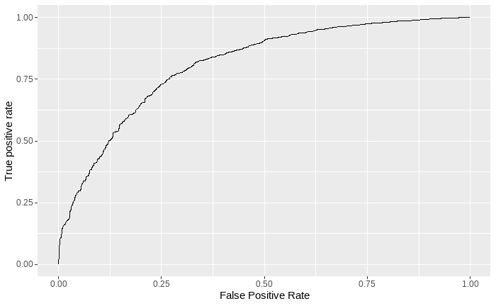

```r
#add predictions to the test dataset using the model
test_nrating_regression_preds <- test_nrating_regression %>%
   add_predictions(mod_nrating_no_econ, type = "response") %>%
   mutate(predicted_good = pred >= 0.6)

#create roc object
roc_obj_nrating_regression_test <- test_nrating_regression_preds %>%
  roc(response = neighbourhood_rating_good, predictor = pred)#predictor is the probability column
#plot the roc object
ggroc(data = roc_obj_nrating_regression_test, legacy.axes = TRUE)+
  labs(x = "False Positive Rate", y = "True positive rate")
```

```r
#get auc for model performance on test data
auc(roc_obj_nrating_regression_test)
```

```
Area under the curve: 0.8095
```

## Compare Logistic regression with Random forest

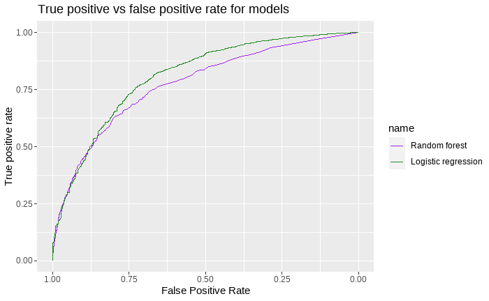

```r
#plot roc curves for both models on same graph
ggroc(list("Random forest" = roc_obj_nrating_tree, "Logistic regression" = roc_obj_nrating_regression_test))+
  labs(title = "True positive vs false positive rate for models",
       x = "False Positive Rate", y = "True positive rate") +
  scale_colour_manual(values = c("purple", "forest green"))
```

```r
#Get AUC for regression on test dataset
auc(roc_obj_nrating_regression_test)
```

```
Area under the curve: 0.8095
```

```r
#Get AUC for random forest performance on test dataset
auc(roc_obj_nrating_tree)
```

```
Area under the curve: 0.7744
```

```r
#Get AUC confidence intervals for regression
ci.auc(roc_obj_nrating_regression_test)
```

```
95% CI: 0.7935-0.8255 (DeLong)
```

```r
#Get AUC confidence intervals for random forest
ci.auc(roc_obj_nrating_tree)
```

```
95% CI: 0.7567-0.7921 (DeLong)
```